# Introduction to Jupyter Notebook

### Use of AI: can be used, but must be reported.

### AI shall not be used to complete the whole assignment.

## Execute every code cell and also take a look at the code and try to understand what is happening.

You can execute by clicking the "Run this cell" -button above. Or test and find out what Ctrl-Enter and Shift-Enter do and what is their difference.

Always wait until the cell is run. If you get errors, fix them before going any further.

### Jupyter Notebook can be used to run basic Python operations

- Results will be shown when you run the cell including the code

```python
print ('Hello World')
```

```
Hello World
```

```python
2 * 5
```

```
10
```

### Libraries for Data Management

```python
# Take the necessary libraries in use
# Preferably always use these namings: pd, np, mp, plt, sns.
import pandas as pd # library for data management with DataFrames
import numpy as np  # library for efficient calculations
import matplotlib as mp # most important library for graphs
import matplotlib.pyplot as plt # alias for plotting with Matplotlib
import seaborn as sns # Another library for graphics - uses Matplotlib
```

### Data is often read from a csv, xlsx (Excel), etc. format into Python's Pandas DataFrame. DataFrame is an important concept in data management / handling.

Read and find out, what a dataframe actually is:

https://www.geeksforgeeks.org/creating-a-pandas-dataframe/

### Demonstration how to create a DataFrame "manually"

```python
# Creation of DataFrame 'df'
# Dictionary used to store the values
values = {'Name':['Joe','Suzy','Leena','Ville','Kalle','Mary','Jim'],
          'Age':[26,25,30,32,34,25,23],
          'Points':[6,4,2,3,4,5,6],
          'Gender':['male','female','female','male','male','female','male']}
df = pd.DataFrame(values)
df  # present the DataFrame
# First column contains index, starting from 0. Notice, that index is added automatically to the dataframe.
# First row contains names of the variable
# Each row contains index and values for all data per variable
```

|  | Name | Age | Points | Gender |
| --- | --- | --- | --- | --- |
| 0 | Joe | 26 | 6 | male |
| 1 | Suzy | 25 | 4 | female |
| 2 | Leena | 30 | 2 | female |
| 3 | Ville | 32 | 3 | male |
| 4 | Kalle | 34 | 4 | male |
| 5 | Mary | 25 | 5 | female |
| 6 | Jim | 23 | 6 | male |

## Examples of Statistical Measurements

### Pandas can be used to present statistical measures from DataFrame such as:

- Mean: mean()
- Standard Deviation: std()
- Median: median()
- Mode: mode()

Make sure you understand all the measures mentioned above

### Descriptive Statistics

- Basic descriptive statistic for a variable.

```python
# mean and median of the variable Points
df.Points.mean()
df.Points.median()
```

```
4.0
```

Why was only one thing (the median) printed out...? Why was the mean not printed out? Find out.

Better use print(), if you want to print out multiple things in one code cell...

```python
print(df.Points.mean())
print(df.Points.median())
```

```
4.285714285714286
4.0
```

And even better is to add some more information:

```python
print("The mean of the points is:", df.Points.mean())
print("The median of the points is:", df.Points.median())
```

```
The mean of the points is: 4.285714285714286
The median of the points is: 4.0
```

You can also round the results:

```python
print("The mean of the points is:", round(df.Points.mean(), 2))
```

```
The mean of the points is: 4.29
```

```python
# Descriptive statistics for all the variables
df.describe()
```

|  | Age | Points |
| --- | --- | --- |
| count | 7.000000 | 7.000000 |
| mean | 27.857143 | 4.285714 |
| std | 4.140393 | 1.496026 |
| min | 23.000000 | 2.000000 |
| 25% | 25.000000 | 3.500000 |
| 50% | 26.000000 | 4.000000 |
| 75% | 31.000000 | 5.500000 |
| max | 34.000000 | 6.000000 |

### Task 1

- Show statistical measures for above data
- Find mean, standard deviation and median for one quantitative variable.

```python
# Show statistical measures
# - Mean: mean()
# - Standard Deviation: std()
# - Median: median()
# - Mode: mode()

print("1. Mean of the dataframe")
print(df.mean(numeric_only=True))

print("\r\n2. Standard Deviation")
print(df.std(numeric_only=True))

print("\r\n3. Median of the dataframe")
print(df.median(numeric_only=True))

print("\r\n4. Mode of the dataframe")
print(df.mode(numeric_only=True))
```

```
1. Mean of the dataframe
Age       27.857143
Points     4.285714
dtype: float64

2. Standard Deviation
Age       4.140393
Points    1.496026
dtype: float64

3. Median of the dataframe
Age       26.0
Points     4.0
dtype: float64

4. Mode of the dataframe
    Age  Points
0  25.0       4
1   NaN       6
```

### Reading data from a file to a dataframe.

##### Read Excel-sheet containing data for following variables.

##### Make sure you have saved the Travellers.xlsx into the same folder where this Jupyter Notebook is.

'Travellers.xlsx'

- Gender (of the person)
- How (person like to travel)
- Age (of the person)
- Target (type of the trip)
- Money_used (person uses during a trip in Euros)
- Favorite_country (person like to travel)
- Trips_year (person typically has in year)
- Trip_Length (person has typicall in days)

```python
# Load some data from Excel file
trips = pd.read_excel("Travellers.xlsx" ,sheet_name='Data')

# Always check, how the data looks like!
trips.head()
```

|  | Gender | How | Age | Target | Money_used | Favorite_country | Trips_year | Trip_Length |
| --- | --- | --- | --- | --- | --- | --- | --- | --- |
| 0 | Male | Alone | 23 | Towns | 800 | Italy | 3 | 3 |
| 1 | Female | Alone | 21 | Beach | 1000 | Spain | 1 | 7 |
| 2 | Female | Friends | 27 | Towns | 1200 | Italy | 3 | 4 |
| 3 | Male | Family | 42 | Beach | 3000 | Greece | 2 | 7 |
| 4 | Female | Family | 37 | Beach | 3800 | Greece | 2 | 7 |

### Task 2

- Find descriptive statistics for the DataFrame
- Mean, standar deviation, ...

```python
# Task 2
# Find descriptive statistics for the DataFrame
trips.describe()
```

|  | Age | Money_used | Trips_year | Trip_Length |
| --- | --- | --- | --- | --- |
| count | 40.000000 | 40.000000 | 40.000000 | 40.000000 |
| mean | 28.900000 | 1570.000000 | 2.225000 | 6.500000 |
| std | 8.292103 | 831.803724 | 1.049725 | 1.934836 |
| min | 19.000000 | 500.000000 | 1.000000 | 3.000000 |
| 25% | 22.750000 | 1000.000000 | 1.750000 | 5.000000 |
| 50% | 26.000000 | 1200.000000 | 2.000000 | 7.000000 |
| 75% | 36.250000 | 1850.000000 | 3.000000 | 7.000000 |
| max | 48.000000 | 3800.000000 | 5.000000 | 14.000000 |

```python
# Task 2
# Mean, standar deviation, ...
print("1. Mean of the trips")
print(trips.mean(numeric_only=True))

print("\r\n2. Standard Deviation of the trips")
print(trips.std(numeric_only=True))

print("\r\n3. Median of the trips")
print(trips.median(numeric_only=True))
```

```
1. Mean of the trips
Age              28.900
Money_used     1570.000
Trips_year        2.225
Trip_Length       6.500
dtype: float64

2. Standard Deviation of the trips
Age              8.292103
Money_used     831.803724
Trips_year       1.049725
Trip_Length      1.934836
dtype: float64

3. Median of the trips
Age              26.0
Money_used     1200.0
Trips_year        2.0
Trip_Length       7.0
dtype: float64
```

## Plotting quantitative data

- Histogram is used to show the distribution of quantitative data
- plot.hist using Matplotlib (https://matplotlib.org/stable/api/_as_gen/matplotlib.pyplot.hist.html)
- sns.histplot using Seaborn (https://seaborn.pydata.org/generated/seaborn.histplot.html)

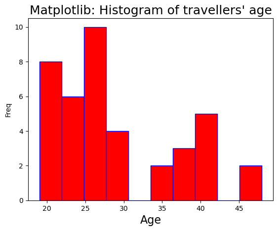

```python
plt.hist(trips.Age, bins=10, color='r',edgecolor='blue')
plt.xlabel('Age', fontsize=16)
plt.ylabel("Freq")
plt.title("Matplotlib: Histogram of travellers' age", fontsize=18)
plt.show()
```

### Histogram with Seaborn

- Seaborn is another library for graphics
- Based on Matplotlib
- histplot is a function in Seaborn for Historgrams
- https://seaborn.pydata.org/generated/seaborn.histplot.html

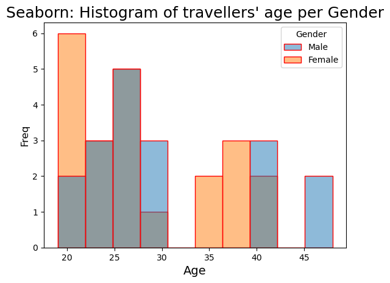

```python
sns.histplot(data = trips, x= 'Age', color='yellow',
             edgecolor ='red',bins=10, hue = 'Gender')
plt.xlabel('Age', fontsize=14)
plt.ylabel('Freq', fontsize=12)
plt.title("Seaborn: Histogram of travellers' age per Gender", fontsize=18)
plt.show()
```

##### Note: Using parameter multiple you get separate bars per variable you have in hue parameter

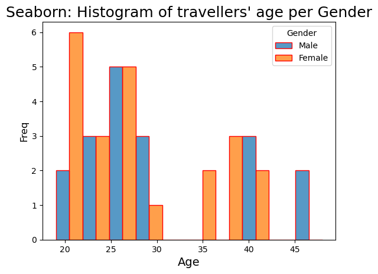

```python
sns.histplot(data = trips, x= 'Age', color='yellow',
             edgecolor ='red',bins=10, hue = 'Gender', multiple = 'dodge')
plt.xlabel('Age', fontsize=14)
plt.ylabel('Freq', fontsize=12)
plt.title("Seaborn: Histogram of travellers' age per Gender", fontsize=18)
plt.show()
```

Modify the histogram's parameters and labels in order to see, what do they do.

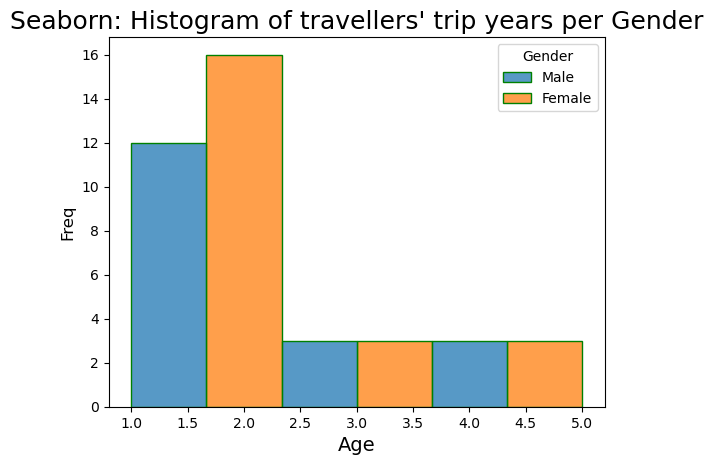

```python
# Modify some parameters

sns.histplot(data = trips, x= 'Trips_year', color='blue',
             edgecolor ='green',bins=3, hue = 'Gender', multiple = 'dodge')
plt.xlabel('Age', fontsize=14)
plt.ylabel('Freq', fontsize=12)
plt.title("Seaborn: Histogram of travellers' trip years per Gender", fontsize=18)
plt.show()
```

## Open datasets

- There is available lot of free datasets that can be used for study
- Seaborn offers easy way to acces to them
- load_dataset
- https://seaborn.pydata.org/generated/seaborn.load_dataset.html

```python
# see dataset available
sns.get_dataset_names()
```

```
['anagrams',
 'anscombe',
 'attention',
 'brain_networks',
 'car_crashes',
 'diamonds',
 'dots',
 'dowjones',
 'exercise',
 'flights',
 'fmri',
 'geyser',
 'glue',
 'healthexp',
 'iris',
 'mpg',
 'penguins',
 'planets',
 'seaice',
 'taxis',
 'tips',
 'titanic']
```

```python
tips = sns.load_dataset('tips')
tips.head()
```

|  | total_bill | tip | sex | smoker | day | time | size |
| --- | --- | --- | --- | --- | --- | --- | --- |
| 0 | 16.99 | 1.01 | Female | No | Sun | Dinner | 2 |
| 1 | 10.34 | 1.66 | Male | No | Sun | Dinner | 3 |
| 2 | 21.01 | 3.50 | Male | No | Sun | Dinner | 3 |
| 3 | 23.68 | 3.31 | Male | No | Sun | Dinner | 2 |
| 4 | 24.59 | 3.61 | Female | No | Sun | Dinner | 4 |

```python
# Info about data and types
tips.info()
```

```
<class 'pandas.core.frame.DataFrame'>
RangeIndex: 244 entries, 0 to 243
Data columns (total 7 columns):
 #   Column      Non-Null Count  Dtype
---  ------      --------------  -----
 0   total_bill  244 non-null    float64
 1   tip         244 non-null    float64
 2   sex         244 non-null    category
 3   smoker      244 non-null    category
 4   day         244 non-null    category
 5   time        244 non-null    category
 6   size        244 non-null    int64
dtypes: category(4), float64(2), int64(1)
memory usage: 7.4 KB
```

### Task 3

- Create histograms using the 'tips' data!
- At least two different graphs, one with Matplotlib and one with Seaborn

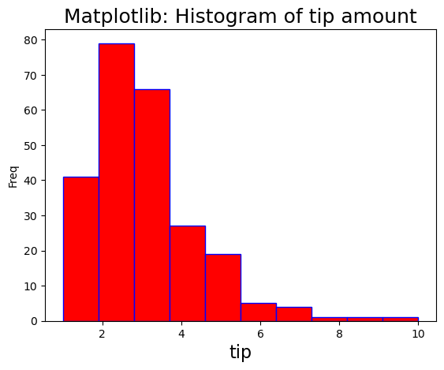

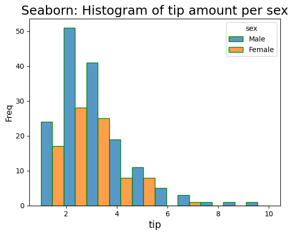

```python
# Task 3
# Matplotlib — histogram of the quantitative variable 'tip'
plt.hist(tips.tip, bins=10, color='r', edgecolor='blue')
plt.xlabel('tip', fontsize=16)
plt.ylabel("Freq")
plt.title("Matplotlib: Histogram of tip amount", fontsize=18)
plt.show()

# Seaborn — histogram of 'tip' grouped by 'sex'
sns.histplot(data=tips, x='tip', color='blue',
             edgecolor='green', bins=10, hue='sex', multiple='dodge')
plt.xlabel('tip', fontsize=14)
plt.ylabel('Freq', fontsize=12)
plt.title("Seaborn: Histogram of tip amount per sex", fontsize=18)
plt.show()
```

## Plotting Qualitative data

### Bar graphs

- Plot qualitative data

#### Seaborn countplot

- https://seaborn.pydata.org/generated/seaborn.countplot.html

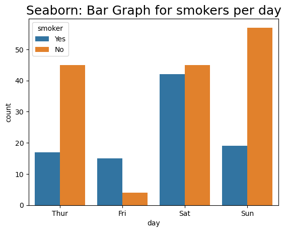

```python
# make bar graph for smokers per day
sns.countplot(data = tips, x='day', hue = 'smoker')
plt.title("Seaborn: Bar Graph for smokers per day", fontsize=18)
plt.show()
```

### Task 4

- Create other bar graphs using the 'tips' data!
- At least two different graphs

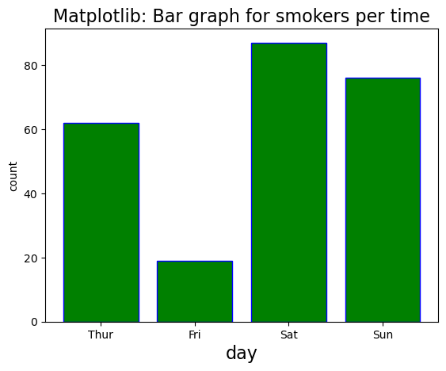

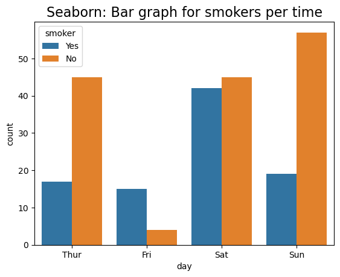

```python
# Create other bar grahp
# Matplotlib — bar chart
frequencies = tips.day.value_counts().sort_index() # sort by day

plt.bar(frequencies.index,  frequencies.values, color='green', edgecolor='blue')
plt.xlabel('day', fontsize=16)
plt.ylabel("count")
plt.title("Matplotlib: Bar graph for smokers per time", fontsize=16)
plt.show()
# Seaborn
sns.countplot(data=tips, x='day', hue='smoker')
plt.title("Seaborn: Bar graph for smokers per time", fontsize=16)
plt.show()
```

### Task 5

- What is the difference between a histogram and bar chart?

Double click this Markdown cell and write your answer here:

- Histogram: A chart that groups continuous numerical values into bins (ranges) to show the frequency distribution of continuous data.
- Bar Chart: A chart that is used to display and compare discrete values across distinct categories.

### Task 6, AI statement

- I use Gemini to explain concepts I am not clear about, such as 'What is the bins parameter for a histogram chart?'
- I also use Gemini or other LLMs to explain code I don't fully understand, including specific operators (even though I didn't use them in this assignment).
- Finally, I use Gemini to check and correct my English grammar.

### Task return

- File > Save and Export Notebook As > HTML
- Then take a look the produced HTML that it looks ok and readable
- Return to Itslearning, only the html document is returned, *not the .ipynb